# Activity: Structure your data

## Introduction

In this activity, you will practice structuring, an **exploratory data analysis (EDA)** step that helps data science projects move forward. During EDA, when working with data that contains aspects of date and time, "datetime" transformations are integral to better understanding the data. As a data professional, you will encounter datetime transformations quite often as you determine how to format your data to suit the problems you want to solve or the questions you want to answer. This activity gives you an opportunity to apply these skills and prepare you for future EDA, where you will need to determine how best to structure your data.

In this activity, you are a member of an analytics team that provides insights to an investing firm. To help them decide which companies to invest in next, the firm wants insights into **unicorn companies**–companies that are valued at over one billion dollars.

You will work with a dataset about unicorn companies, discovering characteristics of the data, structuring the data in ways that will help you draw meaningful insights, and using visualizations to analyze the data. Ultimately, you will draw conclusions about what significant trends or patterns you find in the dataset. This will develop your skills in EDA and your knowledge of functions that allow you to structure data.

## Step 1: Imports

### Import relevant libraries and modules

Import the relevant Python libraries and modules that you will need to use. In this activity, you will use `pandas`, `numpy`, `seaborn`, and `matplotlib.pyplot`.

```python
# Import the relevant Python libraries and modules needed in this lab.

import pandas as pd
import numpy as np
import seaborn as sns
import matplotlib.pyplot as plt
```

### Load the dataset into a DataFrame

The dataset provided is in the form of a csv file named `Unicorn_Companies.csv` and contains a subset of data on unicorn companies. As shown in this cell, the dataset has been automatically loaded in for you. You do not need to download the .csv file, or provide more code, in order to access the dataset and proceed with this lab. Please continue with this activity by completing the following instructions.

```python
# RUN THIS CELL TO IMPORT YOUR DATA.

companies = pd.read_csv("Unicorn_Companies.csv")
```

## Step 2: Data exploration

### Display the first 10 rows of the data

In this section, you will discover what the dataset entails and answer questions to guide your exploration and analysis of the data. This is an important step in EDA.

To begin, display the first 10 rows of the data to get an understanding of how the dataset is structured.

```python
# Display the first 10 rows of the data.

companies.head(10)
```

|  | Company | Valuation | Date Joined | Industry | City | Country/Region | Continent | Year Founded | Funding | Select Investors |
| --- | --- | --- | --- | --- | --- | --- | --- | --- | --- | --- |
| 0 | Bytedance | $180B | 4/7/17 | Artificial intelligence | Beijing | China | Asia | 2012 | $8B | Sequoia Capital China, SIG Asia Investments, S... |
| 1 | SpaceX | $100B | 12/1/12 | Other | Hawthorne | United States | North America | 2002 | $7B | Founders Fund, Draper Fisher Jurvetson, Rothen... |
| 2 | SHEIN | $100B | 7/3/18 | E-commerce & direct-to-consumer | Shenzhen | China | Asia | 2008 | $2B | Tiger Global Management, Sequoia Capital China... |
| 3 | Stripe | $95B | 1/23/14 | Fintech | San Francisco | United States | North America | 2010 | $2B | Khosla Ventures, LowercaseCapital, capitalG |
| 4 | Klarna | $46B | 12/12/11 | Fintech | Stockholm | Sweden | Europe | 2005 | $4B | Institutional Venture Partners, Sequoia Capita... |
| 5 | Canva | $40B | 1/8/18 | Internet software & services | Surry Hills | Australia | Oceania | 2012 | $572M | Sequoia Capital China, Blackbird Ventures, Mat... |
| 6 | Checkout.com | $40B | 5/2/19 | Fintech | London | United Kingdom | Europe | 2012 | $2B | Tiger Global Management, Insight Partners, DST... |
| 7 | Instacart | $39B | 12/30/14 | Supply chain, logistics, & delivery | San Francisco | United States | North America | 2012 | $3B | Khosla Ventures, Kleiner Perkins Caufield & By... |
| 8 | JUUL Labs | $38B | 12/20/17 | Consumer & retail | San Francisco | United States | North America | 2015 | $14B | Tiger Global Management |
| 9 | Databricks | $38B | 2/5/19 | Data management & analytics | San Francisco | United States | North America | 2013 | $3B | Andreessen Horowitz, New Enterprise Associates... |

### Identify the number of rows and columns

Identify the number of rows and columns in the dataset. This will help you get a sense of how much data you are working with.

```python
# Identify the number of rows and columns in the dataset.

companies.shape
```

```
(1074, 10)
```

**Question:** How many rows and columns are in the dataset? How many unicorn companies are there? How many aspects are shown for each company?

- Number of rows: 1074
- Number of unicorn companies: 1074
- Number of aspects per company: 10

### Check for duplicates in the data

```python
# Check for duplicates.

companies.duplicated()
```

```
0       False
1       False
2       False
3       False
4       False
        ...
1069    False
1070    False
1071    False
1072    False
1073    False
Length: 1074, dtype: bool
```

**Question:** Based on the preceding output, are there any duplicates in the dataset?

No, there are no duplicates in the dataset.

### Display the data types of the columns

Knowing the data types of the columns is helpful because it indicates what types of analysis and aggregation can be done, how a column can be transformed to suit specific tasks, and so on. Display the data types of the columns.

```python
# Display the data types of the columns.

companies.dtypes
```

```
Company             object
Valuation           object
Date Joined         object
Industry            object
City                object
Country/Region      object
Continent           object
Year Founded         int64
Funding             object
Select Investors    object
dtype: object
```

**Question:** What do you notice about the data types of the columns in the dataset?

The columns Company, Valuation, Date Joined, Industry, City, Country/Region, Funding, and Select Investors are of type object, which likely means they contain strings or mixed data. The year Founded column is an integer, indicating it contains numeric year values.

**Question:** How would you sort this dataset in order to get insights about when the companies were founded? Then, how would you arrange the data from companies that were founded the earliest to companies that were founded the latest?

To get insights about when the companies were founded, sort the dataset by the Year Founded column in ascending order. This will arrange companies from those founded the earliest to those founded the latest.

### Sort the data

In this section, you will continue your exploratory data analysis by structuring the data. This is an important step in EDA, as it allows you to glean valuable and interesting insights about the data afterwards.

To begin, sort the data so that you can get insights about when the companies were founded. Consider whether it would make sense to sort in ascending or descending order based on what you would like to find.

```python
# Sort `companies` and display the first 10 rows of the resulting DataFrame.

companies_sorted = companies.sort_values(by='Year Founded', ascending=True)
companies_sorted.head(10)
```

|  | Company | Valuation | Date Joined | Industry | City | Country/Region | Continent | Year Founded | Funding | Select Investors |
| --- | --- | --- | --- | --- | --- | --- | --- | --- | --- | --- |
| 189 | Otto Bock HealthCare | $4B | 6/24/17 | Health | Duderstadt | Germany | Europe | 1919 | $0M | EQT Partners |
| 373 | Promasidor Holdings | $2B | 11/8/16 | Consumer & retail | Bryanston | South Africa | Asia | 1979 | $556M | IFC, Ajinomoto |
| 699 | Five Star Business Finance | $1B | 3/26/21 | Other | Chennai | India | Asia | 1984 | $456M | Sequoia Capital India, Tiger Global Management... |
| 840 | Radius Payment Solutions | $1B | 11/27/17 | Fintech | Crewe | United Kingdom | Europe | 1990 | $200M | Inflexion Private Equity |
| 11 | Epic Games | $32B | 10/26/18 | Other | Cary | United States | North America | 1991 | $7B | Tencent Holdings, KKR, Smash Ventures |
| 377 | BGL Group | $2B | 11/24/17 | Fintech | Peterborough | United Kingdom | Europe | 1992 | $696M | CPP Investment Board |
| 1043 | Thirty Madison | $1B | 6/2/21 | Health | New York | United States | North America | 1993 | $210M | Northzone Ventures, Maveron, Johnson & Johnson... |
| 129 | Howden Group Holdings | $5B | 9/29/20 | Other | London | United Kingdom | Europe | 1994 | $187M | General Atlantic, 3i Group, Huagai Capital |
| 118 | Vice Media | $6B | 4/2/11 | Internet software & services | Brooklyn | United States | North America | 1994 | $1B | Technology Crossover Ventures, A&E Television ... |
| 360 | Carzone | $2B | 3/1/19 | E-commerce & direct-to-consumer | Jiangsu | China | Asia | 1995 | $946M | Alibaba Group,Co-Stone Venture Capital, Buhuo ... |

**Question:** What do you observe from the sorting that you performed?

**Question:** Which library would you use to get the count of each distinct value in the `Year Founded` column?

We would use the pandas library to get the count of each distinct value in the Year Founded column. Specifically, you use the value_counts() method.

### Determine the number of companies founded each year

Find out how many companies in this dataset were founded each year. Make sure to display each unique `Year Founded` that occurs in the dataset, and for each year, a number that represents how many companies were founded then.

```python
# Display each unique year that occurs in the dataset
# along with the number of companies that were founded in each unique year.

year_counts = companies['Year Founded'].value_counts().sort_index()
year_counts
```

```
1919      1
1979      1
1984      1
1990      1
1991      1
1992      1
1993      1
1994      2
1995      2
1996      1
1997      1
1998      5
1999      8
2000     11
2001      9
```

[output cut: 21 more lines]

**Question:** What do you observe from the counts of the unique `Year Founded` values in the dataset?

The counts show a significant increase in companies founded from 2000 onwards, with the highest numbers in the 2010s. The number of companies founded each year peaked in 2015 and has generally decreased since then.

**Question:** What kind of graph represents the counts of samples based on a particular feature?

A bar plot is commonly used to represent the counts of samples based on a particular feature. It shows the frequency of each unique value of the feature along the x-axis and the corresponding count on the y-axis.

Plot a histogram of the `Year Founded` feature.

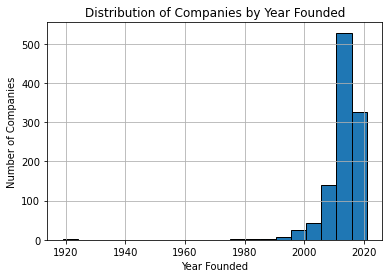

```python
# Plot a histogram of the Year Founded feature.
companies['Year Founded'].hist(bins=20, edgecolor='black')
plt.xlabel('Year Founded')
plt.ylabel('Number of Companies')
plt.title('Distribution of Companies by Year Founded')

plt.show()
```

**Question:** If you want to compare when one company joined unicorn status to when another company joined, how would you transform the `Date Joined` column to gain that insight? To answer this question, notice the data types.

To compare when one company joined unicorn status to another, I would transform the Date Joined column to a datetime datatype. This would allow for easier comparison of dates, such as calculating the difference between the joining dates of two companies. Since the Date Joined column is currently an object type, I would use pd.to_datetime() to convert it into the proper format.

### Convert the `Date Joined` column to datetime

Convert the `Date Joined` column to datetime. This will split each value into year, month, and date components, allowing you to later gain insights about when a company gained unicorn status with respect to each component.

```python
# Convert the `Date Joined` column to datetime.
# Update the column with the converted values.

companies['Date Joined']=pd.to_datetime(companies['Date Joined'])

# Display the data types of the columns in `companies`
# to confirm that the update actually took place.

companies.dtypes
```

```
Company                     object
Valuation                   object
Date Joined         datetime64[ns]
Industry                    object
City                        object
Country/Region              object
Continent                   object
Year Founded                 int64
Funding                     object
Select Investors            object
dtype: object
```

**Question:** How would you obtain the names of the months when companies gained unicorn status?

To obtain the names of the months when companies gained unicorn status, I would use the .dt.month_name() method on the Date Joined. This will give the full month name for each company's joining date.

### Create a `Month Joined` column

Obtain the names of the months when companies gained unicorn status, and use the result to create a `Month Joined` column.

```python
# Obtain the names of the months when companies gained unicorn status.
# Use the result to create a `Month Joined` column.

companies['Month joined'] = companies['Date Joined'].dt.month_name()

# Display the first few rows of `companies`
# to confirm that the new column did get added.

### YOUR CODE HERE ###

companies.head(5)
```

|  | Company | Valuation | Date Joined | Industry | City | Country/Region | Continent | Year Founded | Funding | Select Investors | Month joined |
| --- | --- | --- | --- | --- | --- | --- | --- | --- | --- | --- | --- |
| 0 | Bytedance | $180B | 2017-04-07 | Artificial intelligence | Beijing | China | Asia | 2012 | $8B | Sequoia Capital China, SIG Asia Investments, S... | April |
| 1 | SpaceX | $100B | 2012-12-01 | Other | Hawthorne | United States | North America | 2002 | $7B | Founders Fund, Draper Fisher Jurvetson, Rothen... | December |
| 2 | SHEIN | $100B | 2018-07-03 | E-commerce & direct-to-consumer | Shenzhen | China | Asia | 2008 | $2B | Tiger Global Management, Sequoia Capital China... | July |
| 3 | Stripe | $95B | 2014-01-23 | Fintech | San Francisco | United States | North America | 2010 | $2B | Khosla Ventures, LowercaseCapital, capitalG | January |
| 4 | Klarna | $46B | 2011-12-12 | Fintech | Stockholm | Sweden | Europe | 2005 | $4B | Institutional Venture Partners, Sequoia Capita... | December |

**Question:** Using the 'Date Joined' column, how would you determine how many years it took for companies to reach unicorn status?

To determine how many years it took for companies to reach unicorn status, I would subact the Year Founded from the Date Joined year.

### Create a `Years To Join` column

Determine how many years it took for companies to reach unicorn status, and use the result to create a `Years To Join` column. Adding this to the dataset can help you answer questions you may have about this aspect of the companies.

```python
# Determine how many years it took for companies to reach unicorn status.
# Use the result to create a `Years To Join` column.

companies['Year to Unicorn'] = companies['Date Joined'].dt.year - companies['Year Founded']

# Display the first few rows of `companies`
# to confirm that the new column did get added.

companies.head(5)
```

|  | Company | Valuation | Date Joined | Industry | City | Country/Region | Continent | Year Founded | Funding | Select Investors | Month joined | Year to Unicorn |
| --- | --- | --- | --- | --- | --- | --- | --- | --- | --- | --- | --- | --- |
| 0 | Bytedance | $180B | 2017-04-07 | Artificial intelligence | Beijing | China | Asia | 2012 | $8B | Sequoia Capital China, SIG Asia Investments, S... | April | 5 |
| 1 | SpaceX | $100B | 2012-12-01 | Other | Hawthorne | United States | North America | 2002 | $7B | Founders Fund, Draper Fisher Jurvetson, Rothen... | December | 10 |
| 2 | SHEIN | $100B | 2018-07-03 | E-commerce & direct-to-consumer | Shenzhen | China | Asia | 2008 | $2B | Tiger Global Management, Sequoia Capital China... | July | 10 |
| 3 | Stripe | $95B | 2014-01-23 | Fintech | San Francisco | United States | North America | 2010 | $2B | Khosla Ventures, LowercaseCapital, capitalG | January | 4 |
| 4 | Klarna | $46B | 2011-12-12 | Fintech | Stockholm | Sweden | Europe | 2005 | $4B | Institutional Venture Partners, Sequoia Capita... | December | 6 |

**Question:** Which year would you like to gain more insight on with respect when companies attained unicorn status, and why?